# Place analyses

2019-08-21T11:04:35+02:00

The final section of the template produces tabular analysis outputs related to *place*. If you have shapefiles for your situation, you can also produce maps.

### Tabular place analyses (non-maps)

To get a basic **descriptive table of cases by region** (which in our case was originally the variable *quartier* from the raw linelist), we use `tab_linelist()` on the variable `patient_origin`, with columns by `patient_facility_type` (inpatient, outpatient, or missing).

```r
# Descriptive table of cases by region and facility type
tab_linelist(linelist_cleaned, patient_origin,
             strata = patient_facility_type,
             col_total = TRUE, row_total = TRUE) %>%
  select(-variable) %>%
  rename("Region" = value) %>%
  rename_redundant("%" = proportion) %>%
  augment_redundant(" (n)" = " n$") %>%
  kable(digits = 1)
```

| Region | Inpatient (n) | % | Outpatient (n) | % | Missing (n) | % | Total |
| --- | --- | --- | --- | --- | --- | --- | --- |
| AB GARA | 0 | 0.0 | 0 | 0.0 | 1 | 0.2 | 1 |
| ABLELAYE | 5 | 6.0 | 1 | 0.1 | 2 | 0.3 | 8 |
| ABOUDEA | 1 | 1.2 | 0 | 0.0 | 0 | 0.0 | 1 |
| ADAMRE | 2 | 2.4 | 22 | 3.2 | 24 | 3.7 | 48 |
| ADJABONA | 0 | 0.0 | 0 | 0.0 | 2 | 0.3 | 2 |
| AFFOUSSE | 1 | 1.2 | 1 | 0.1 | 0 | 0.0 | 2 |
| AL-FRECHE | 1 | 1.2 | 0 | 0.0 | 0 | 0.0 | 1 |
| AL-HOUGNA | 1 | 1.2 | 10 | 1.5 | 10 | 1.5 | 21 |
| AL-MOURA | 1 | 1.2 | 0 | 0.0 | 0 | 0.0 | 1 |
| AL ALAK | 0 | 0.0 | 1 | 0.1 | 0 | 0.0 | 1 |
| AL HOUA | 0 | 0.0 | 0 | 0.0 | 1 | 0.2 | 1 |
| AL KOUCK | 0 | 0.0 | 1 | 0.1 | 0 | 0.0 | 1 |
| AL MIDODIL | 1 | 1.2 | 0 | 0.0 | 0 | 0.0 | 1 |
| ALBAYADI | 1 | 1.2 | 1 | 0.1 | 0 | 0.0 | 2 |
| ALBOUKHASS | 0 | 0.0 | 6 | 0.9 | 6 | 0.9 | 12 |
| ALKASSÉ | 4 | 4.8 | 15 | 2.2 | 5 | 0.8 | 24 |
| AM-DOUMA | 0 | 0.0 | 1 | 0.1 | 0 | 0.0 | 1 |
| AM ASSALA | 0 | 0.0 | 1 | 0.1 | 0 | 0.0 | 1 |
| AM BADARO 1 | 0 | 0.0 | 1 | 0.1 | 0 | 0.0 | 1 |
| AM KIFEO | 1 | 1.2 | 0 | 0.0 | 0 | 0.0 | 1 |
| AMANASISSE | 0 | 0.0 | 1 | 0.1 | 0 | 0.0 | 1 |
| AMBARITE | 0 | 0.0 | 3 | 0.4 | 1 | 0.2 | 4 |
| AMCHOKA | 1 | 1.2 | 0 | 0.0 | 0 | 0.0 | 1 |
| AMDIREDIMAT | 1 | 1.2 | 0 | 0.0 | 0 | 0.0 | 1 |
| AMDJALAT | 0 | 0.0 | 2 | 0.3 | 2 | 0.3 | 4 |
| AMMANASIS | 0 | 0.0 | 0 | 0.0 | 2 | 0.3 | 2 |
| AMSINENE | 3 | 3.6 | 5 | 0.7 | 5 | 0.8 | 13 |
| ANALA | 2 | 2.4 | 2 | 0.3 | 4 | 0.6 | 8 |
| ANFANDOCK | 5 | 6.0 | 26 | 3.8 | 19 | 2.9 | 50 |
| ANGUITEI | 0 | 0.0 | 0 | 0.0 | 1 | 0.2 | 1 |

[output cut: 63 more lines]

To get a **descriptive table by patient outcome** we set `strata = exit_status2`. We can also restrict the analysis to inpatients only by inserting the function `filter()` into the first argument of `tab_linelist`. `tab_linelist()` expects a data frame for it’s first argument, and it receives the filtered `linelist_cleaned` - this is an example of “nested”" functions (one function inside another).

```r
# get counts and props of region by outcome among inpatients
# include column and row totals
tab_linelist(filter(linelist_cleaned,
                    patient_facility_type == "Inpatient"),
             patient_origin, strata = exit_status2,
             col_total = TRUE, row_total = TRUE) %>%
  select(-variable) %>%
  rename("Region" = value) %>%
  rename_redundant("%" = proportion) %>%
  augment_redundant(" (n)" = " n$") %>%
  kable(digits = 1)
```

| Region | Dead (n) | % | Discharged (n) | % | Left (n) | % | Missing (n) | % | Total |
| --- | --- | --- | --- | --- | --- | --- | --- | --- | --- |
| ABLELAYE | 1 | 7.7 | 4 | 7.8 | 0 | 0 | 0 | 0.0 | 5 |
| ABOUDEA | 0 | 0.0 | 1 | 2.0 | 0 | 0 | 0 | 0.0 | 1 |
| ADAMRE | 0 | 0.0 | 0 | 0.0 | 1 | 50 | 1 | 5.9 | 2 |
| AFFOUSSE | 0 | 0.0 | 1 | 2.0 | 0 | 0 | 0 | 0.0 | 1 |
| AL-FRECHE | 0 | 0.0 | 1 | 2.0 | 0 | 0 | 0 | 0.0 | 1 |
| AL-HOUGNA | 1 | 7.7 | 0 | 0.0 | 0 | 0 | 0 | 0.0 | 1 |
| AL-MOURA | 0 | 0.0 | 1 | 2.0 | 0 | 0 | 0 | 0.0 | 1 |
| AL MIDODIL | 0 | 0.0 | 1 | 2.0 | 0 | 0 | 0 | 0.0 | 1 |
| ALBAYADI | 0 | 0.0 | 1 | 2.0 | 0 | 0 | 0 | 0.0 | 1 |
| ALKASSÉ | 0 | 0.0 | 4 | 7.8 | 0 | 0 | 0 | 0.0 | 4 |
| AM KIFEO | 0 | 0.0 | 1 | 2.0 | 0 | 0 | 0 | 0.0 | 1 |
| AMCHOKA | 0 | 0.0 | 1 | 2.0 | 0 | 0 | 0 | 0.0 | 1 |
| AMDIREDIMAT | 0 | 0.0 | 1 | 2.0 | 0 | 0 | 0 | 0.0 | 1 |
| AMSINENE | 1 | 7.7 | 0 | 0.0 | 0 | 0 | 2 | 11.8 | 3 |
| ANALA | 0 | 0.0 | 0 | 0.0 | 1 | 50 | 1 | 5.9 | 2 |
| ANFANDOCK | 1 | 7.7 | 4 | 7.8 | 0 | 0 | 0 | 0.0 | 5 |
| ARDO | 0 | 0.0 | 2 | 3.9 | 0 | 0 | 1 | 5.9 | 3 |
| ATOUA | 0 | 0.0 | 1 | 2.0 | 0 | 0 | 0 | 0.0 | 1 |
| BAUNE | 0 | 0.0 | 1 | 2.0 | 0 | 0 | 0 | 0.0 | 1 |
| DARWAL | 0 | 0.0 | 1 | 2.0 | 0 | 0 | 0 | 0.0 | 1 |
| DELEBAE | 1 | 7.7 | 0 | 0.0 | 0 | 0 | 0 | 0.0 | 1 |
| DIFFIR | 0 | 0.0 | 2 | 3.9 | 0 | 0 | 0 | 0.0 | 2 |
| DIJEKHINÉ | 0 | 0.0 | 1 | 2.0 | 0 | 0 | 0 | 0.0 | 1 |
| DILEMA | 0 | 0.0 | 2 | 3.9 | 0 | 0 | 1 | 5.9 | 3 |
| DINGUESS | 1 | 7.7 | 1 | 2.0 | 0 | 0 | 0 | 0.0 | 2 |
| GANATIR | 0 | 0.0 | 4 | 7.8 | 0 | 0 | 1 | 5.9 | 5 |
| GOZ-TAMADJA | 0 | 0.0 | 0 | 0.0 | 0 | 0 | 1 | 5.9 | 1 |
| GOZ DJARAT | 0 | 0.0 | 0 | 0.0 | 0 | 0 | 1 | 5.9 | 1 |
| GOZ MABILE | 1 | 7.7 | 0 | 0.0 | 0 | 0 | 0 | 0.0 | 1 |
| GOZ MABILE 2 | 0 | 0.0 | 0 | 0.0 | 0 | 0 | 1 | 5.9 | 1 |
| HARAZA | 1 | 7.7 | 0 | 0.0 | 0 | 0 | 0 | 0.0 | 1 |
| HILE BARA | 0 | 0.0 | 2 | 3.9 | 0 | 0 | 0 | 0.0 | 2 |
| KACHKACHA | 2 | 15.4 | 1 | 2.0 | 0 | 0 | 0 | 0.0 | 3 |
| MINA | 1 | 7.7 | 1 | 2.0 | 0 | 0 | 0 | 0.0 | 2 |
| MIRÉKIKE | 0 | 0.0 | 1 | 2.0 | 0 | 0 | 0 | 0.0 | 1 |
| MIRER | 0 | 0.0 | 1 | 2.0 | 0 | 0 | 0 | 0.0 | 1 |
| RASSALFIL | 0 | 0.0 | 3 | 5.9 | 0 | 0 | 0 | 0.0 | 3 |
| RIAD | 1 | 7.7 | 1 | 2.0 | 0 | 0 | 1 | 5.9 | 3 |
| SALAMAT | 0 | 0.0 | 2 | 3.9 | 0 | 0 | 0 | 0.0 | 2 |
| SIHEBA | 0 | 0.0 | 1 | 2.0 | 0 | 0 | 0 | 0.0 | 1 |
| TARADONA | 0 | 0.0 | 1 | 2.0 | 0 | 0 | 1 | 5.9 | 2 |
| TARADONA 1 | 0 | 0.0 | 0 | 0.0 | 0 | 0 | 1 | 5.9 | 1 |
| TARADONA 2 | 1 | 7.7 | 1 | 2.0 | 0 | 0 | 3 | 17.6 | 5 |
| TARADONA 3 | 0 | 0.0 | 0 | 0.0 | 0 | 0 | 1 | 5.9 | 1 |
| Total | 13 | 100.0 | 51 | 100.0 | 2 | 100 | 17 | 100.0 | 83 |

**A table of attack rates by region may be useful**

**First**, like when we calculated attack rate by epiweek in the `time_analysis` section, the cases are counted by `patient_origin`. This list of counts is then **joined** to the imported population data for each region **joined by `patient_origin` (the name of the region/quartier)**. These data are stored in the object `cases`.

*Recall that this **join** requires **exact matches* between `patient_origin` values in `linelist_cleaned$patient_origin` and `population_data_region$patient_origin` to match a region’s cases to its population (read more about joins in the advanced R Basics page). In the data cleaning steps we converted the values in `linelist_cleaned` to all capital letters to match those in `population_data_region`.

The `ar` object saves the counts, population, and attack rate calculations along with modified column names.

Finally, the table is created with `kable()` and displayed.

```r
# count cases by region
cases <- count(linelist_cleaned, patient_origin) %>%
  # add in population data
  left_join(population_data_region, by = "patient_origin")

# calculate attack rate for region
ar_region <- attack_rate(cases$n, cases$population, multiplier = 10000) %>%
  # add the region column to table
  bind_cols(select(cases, patient_origin), .) %>%
  rename("Region" = patient_origin,
         "Cases (n)" = cases,
         "Population" = population,
         "AR (per 10,000)" = ar,
         "Lower 95%CI" = lower,
         "Upper 95%CI" = upper)
ar_region %>%
  merge_ci_df(e = 4) %>% # merge lower and upper CI in to one column
  rename("95%CI" = ci) %>%  # rename single 95%CI column
  kable(digits = 1, align = "r", format.args = list(big.mark = ",")) # set thousands separator
```

| Region | Cases (n) | Population | AR (per 10,000) | 95%CI |
| --- | --- | --- | --- | --- |
| AB GARA | 1 | - | - | (NA–NA) |
| ABLELAYE | 8 | - | - | (NA–NA) |
| ABOUDEA | 1 | - | - | (NA–NA) |
| ADAMRE | 48 | - | - | (NA–NA) |
| ADJABONA | 2 | 2,350 | 8.5 | (2.33–30.98) |
| AFFOUSSE | 2 | - | - | (NA–NA) |
| AL-FRECHE | 1 | - | - | (NA–NA) |
| AL-HOUGNA | 21 | - | - | (NA–NA) |
| AL-MOURA | 1 | - | - | (NA–NA) |
| AL ALAK | 1 | - | - | (NA–NA) |
| AL HOUA | 1 | - | - | (NA–NA) |
| AL KOUCK | 1 | - | - | (NA–NA) |
| AL MIDODIL | 1 | - | - | (NA–NA) |
| ALBAYADI | 2 | - | - | (NA–NA) |
| ALBOUKHASS | 12 | - | - | (NA–NA) |
| ALKASSÉ | 24 | - | - | (NA–NA) |
| AM-DOUMA | 1 | - | - | (NA–NA) |
| AM ASSALA | 1 | - | - | (NA–NA) |
| AM BADARO 1 | 1 | - | - | (NA–NA) |
| AM KIFEO | 1 | - | - | (NA–NA) |
| AMANASISSE | 1 | - | - | (NA–NA) |
| AMBARITE | 4 | - | - | (NA–NA) |
| AMCHOKA | 1 | - | - | (NA–NA) |
| AMDIREDIMAT | 1 | - | - | (NA–NA) |
| AMDJALAT | 4 | - | - | (NA–NA) |
| AMMANASIS | 2 | - | - | (NA–NA) |
| AMSINENE | 13 | - | - | (NA–NA) |
| ANALA | 8 | - | - | (NA–NA) |
| ANFANDOCK | 50 | - | - | (NA–NA) |
| ANGUITEI | 1 | - | - | (NA–NA) |

[output cut: 63 more lines]

You could then also plot this on a bar chart with confidence intervals.

{{% notice tip %}} There are many quartiers without population denominators that will make the graph difficult to read. Thus, **we modify the code by filtering `ar_region` to remove these** using the opposite (`!`) of the `is.na()` function (see Operators R Basics page). Now any quartiers with missing denominators will not appear in the graph.  
{{% /notice %}}

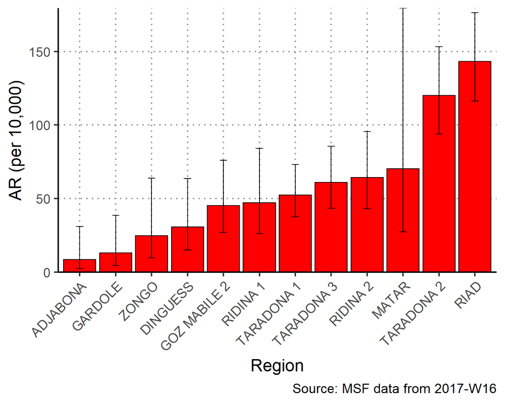

```r
# filter ar for non-zero quartiers
ar_region <- filter(ar_region, !is.na(`AR (per 10,000)`))

# plot with the region on the x axis sorted by increasing ar
# ar value on the y axis
ggplot(ar_region, aes(x = reorder(Region, `AR (per 10,000)`),
               y = `AR (per 10,000)`)) +
  geom_bar(stat = "identity", col = "black", fill = "red") + # plot as bars (identity = as is)
  geom_errorbar(aes(ymin = `Lower 95%CI`, ymax = `Upper 95%CI`), width = 0.2) + # add CIs
  scale_y_continuous(expand = c(0,0)) +  # set origin for axes
  # add labels to axes and below chart
  labs(x = "Region", y = "AR (per 10,000)",
       captions = str_glue("Source: MSF data from {reporting_week}")) +
  epicurve_theme
```

You could also **table mortality rate by region**. A few things to note:

- The first command uses `group_by()` to count cases by `patient_origin`. Then, `filter()` is applied based on the character search function `str_detect()` from the package **stringr**, which looks for “Dead” within the variable `exit_status` - **note: we must change this to reflect our data and have `str_detect()` look in `exit_status2`** (otherwise, the object `deaths` has 0 rows and `mortality_rate()` produces an error).
- The `mortality_rate()` step calculates mortality rates for the regions that had a death.

```r
deaths <- group_by(linelist_cleaned, patient_origin) %>%
  filter(str_detect(exit_status2, "Dead")) %>%
  summarise(deaths = n()) %>% # count deaths by region
  left_join(population_data_region, by = "patient_origin") # merge population data

mortality_rate(deaths$deaths, deaths$population, multiplier = 10000) %>%
  # add the region column to table
  bind_cols(select(deaths, patient_origin), .) %>%
  merge_ci_df(e = 4) %>% # merge the lower and upper CI into one column
  rename("Region" = patient_origin,
         "Deaths" = deaths,
         "Population" = population,
         "Mortality (per 10,000)" = `mortality per 10 000`,
         "95%CI" = ci) %>%
  kable(digits = 1)
```

| Region | Deaths | Population | Mortality (per 10,000) | 95%CI |
| --- | --- | --- | --- | --- |
| ABLELAYE | 1 | - | - | (NA–NA) |
| AL-HOUGNA | 1 | - | - | (NA–NA) |
| AMSINENE | 1 | - | - | (NA–NA) |
| ANFANDOCK | 1 | - | - | (NA–NA) |
| BADINA | 1 | - | - | (NA–NA) |
| DELEBAE | 1 | - | - | (NA–NA) |
| DINGUESS | 1 | 2268 | 4.4 | (0.78–24.93) |
| GOZ MABILE | 1 | - | - | (NA–NA) |
| HARAZA | 1 | - | - | (NA–NA) |
| KACHKACHA | 2 | - | - | (NA–NA) |
| MINA | 1 | - | - | (NA–NA) |
| RIAD | 1 | 6073 | 1.6 | (0.29–9.32) |
| TARADONA 2 | 1 | 5250 | 1.9 | (0.34–10.78) |

### Maps

Mapping in R can be intimidating at first because it is different than ArcGIS, QGIS, or other mapping software that primarily use a point-and-click interface. However, you will see that using commands to create maps can be much faster, more replicable, and transparent for whomever you share code with.

We do have shapefiles for the Am Timan exercise. You can download them from the case study overview page of this website.

*Shapefiles are a format for storing geometric location and attribute data for geographic features - for example **either points (e.g. GPS points of cases or households surveyed), lines (e.g. road network), or polygons (e.g. district boundaries)***

{{% notice tip %}} A shapefile is actually made of several files. Viewing the shapefile in your computer’s internal folders you will often see 4 or 5 files with the same name but different extensions (e.g. .shp, .prj, etc.). As long as these files are located in the same folder the shapefile will load correctly when you import with the .shp extension. {{% /notice %}}

Because we have shapefiles for this exercise, we **must delete the command that generates the fake shapefile** (`map <- gen_polygon(regions = unique(linelist_cleaned$patient_origin))`).

Note the checklist for using shapefiles:

- Your shapefile can be a polygon or points (and polygons do not have to be contiguous - they do not have to touch each other)
- Ensure that the region names in the shapefile match *exactly* the region names in `linelist_cleaned`. (in most shapefiles there is an ID or NAME variable in the spreadsheet file)
- Make sure the coordinate reference system (CRS) of the shapefile is WGS84 (this is the standard coordinate system used by most GPS systems, but it is good to ask whomever collected to data to be sure)

{{% notice tip %}} When giving the name of a shapefile to `here()`, list the file name with a .shp extension. {{% /notice %}}

The `import()` function is wrapped around the `here()` function. The `here()` function makes it easy for R to locate files on your computer. It is best to save the dataset within your R project, and to provide `here()` with any R project subfolder names. You can read more about the `here()` function in the data import R Basics page.

```r
## reading in a shapefile
map <- read_sf(here::here("Quartiersshape.shp"))
```

The next code will check the coordinate reference system (CRS) of the shapefile, as it was read-in. In our exercise, we see an EPSG code of 4326, which is the correct code for WGS84 (you can also see below the EPSG code that the datum is WGS84).

```r
## check the coordinate reference system (CRS)
st_crs(map)
```

```
## Coordinate Reference System:
##   User input: 4326
##   wkt:
## GEOGCS["GCS_WGS_1984",
##     DATUM["WGS_1984",
##         SPHEROID["WGS_84",6378137,298.257223563]],
##     PRIMEM["Greenwich",0],
##     UNIT["Degree",0.017453292519943295],
##     AUTHORITY["EPSG","4326"]]
```

If there is no CRS specified for your shapefile, you can set the CRS to WGS84 with the following command, which uses the EPSG code of 4326.

```r
## set the CRS if not present using EPSG value
## this is the most commonly used
map <- st_set_crs(map, value = 4326) # Sets to WGS84
```

Below we explain each step within the this code chunk, plotting a map based on the attack rate table.

**Create a *categorical* variable of the attack rate.** These categories will appear in the map as the legend - and the regions will be colored by these groups.

```r
## create a categorical variable for plotting
max_ar    <- max(ar_region$`Upper 95%CI`, na.rm = TRUE) # define your highest AR

breakers <- as.integer(c(
                         # include zero as a standalone group
                         0,
                         # 1 to 4 divisions, snapping the boundaries to the nearest 100
                         find_breaks(n = max_ar, breaks = 4, snap = 100)
             ))

## add a categorical variable using the age_categories function
## nb in this case we arent using ages - but it functions the same way!
ar_map <- mutate(ar_region,
             categories = age_categories(`AR (per 10,000)`,
                                         breakers = breakers)
             )
```

**You may need to modify your code so that the join occurs on `Name` in the object `map`, and not `name`.**

{{% notice tip %}} Make sure you modify your `left_join` code to use “Name” with a capital N, as that is how the variable is spelled in the object ‘map’. In your other data these variable names may be completely different and must be changed {{% /notice %}}

The resulting object `mapsub` is a product of this **left join**. A left join will include all values from the Left-hand Side (LHS) and only inlcude values from the Right-hand Side (RHS) if they match to LHS values. Now, the attack rates are joined to the region names and to their GIS geometries. You can verify this by Viewing the object `mapsub` (click on it in the Environment pane).

```r
## join your ar or case counts based on matching shapefile names with regions in your ar table
mapsub <- left_join(map, ar_map, by = c("Name" = "Region"))
```

**Now, `ggplot()` is used to create the map.** Remember that `ggplot()` subcommands must be connected by plus symbols at the end of each line (`+`) (except the last line). Read more about ggplot2 and `ggplot()` in the Advanced R Basics page.

**`geom_sf()`** identifies `mapsub` as providing the data for the map, and filling the polygons by values in the variable `categories`.

**`coord_sf()`** set to `NA` prevents gridlines from being drawn on the map.

**`annotation_scale()`** adds a scalebar at the bottom of the map.

**`scale_fill_brewer()`** uses a color palatte from orange to red (“OrRd”), keeps all color levels even if there are no polygons at that level (`drop=FALSE`), and specifies a title for the legend. If you want a different color scale, use this code from the package **RColorBrewer** to see the possible options (hint: after running this code click “Zoom” in your Plot/Viewer pane to see more clearly). Then replace “OrRd” with your desired code. You can read more about colors [here](http://www.sthda.com/english/wiki/print.php?id=85).

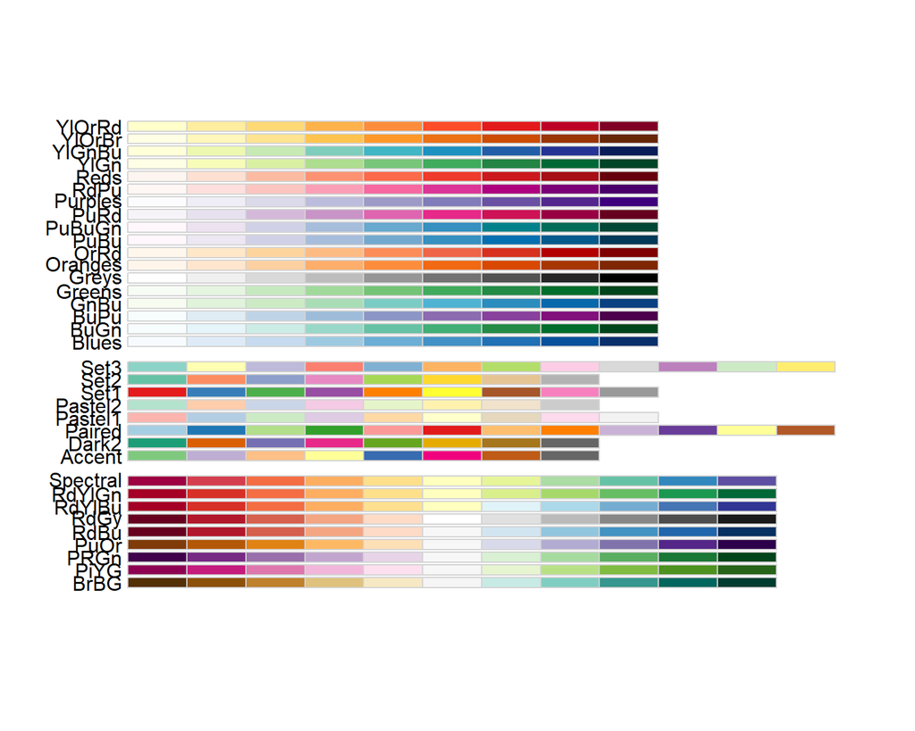

```r
library(RColorBrewer)
display.brewer.all()
```

**`geom_sf_text()`** specifies labels for the polygons, including which variable to use for labels (`Name`), and the text colour. **Again, we need to modify this `ggplot()` reference to the variable “name” to now reference “Name” with a capital N. In your other data the variable may be completely different.**

**`theme_void()`** specifies a theme for the map that does not include coordinates or axes.

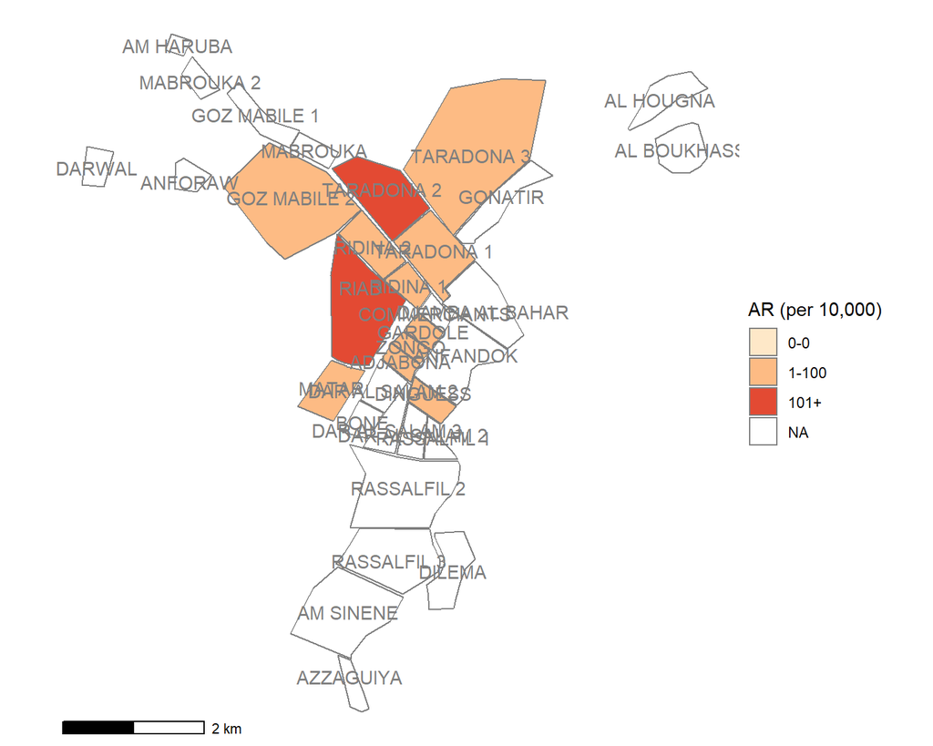

```r
## plotting with polygons ------------------------------------------------------

ggplot() +
  geom_sf(data = mapsub, aes(fill = categories), col = "grey50") + # shapefile as polygon
  coord_sf(datum = NA) + # needed to avoid gridlines being drawn
  annotation_scale() + # add a scalebar
  scale_fill_brewer(drop = FALSE, palette = "OrRd", name = "AR (per 10,000)") +
  geom_sf_text(data = mapsub, aes(label = Name), colour = "grey50") + # label polygons
  theme_void() # remove coordinates and axes
```

**You can use this alternative to make the labels not overlap.**

**`ggrepel()`** arranges point/polygon labels so they do not overlap and are easier to read. You can see more examples of `ggrepel()` [in this vignette](https://mran.microsoft.com/snapshot/2017-08-20/web/packages/ggrepel/vignettes/ggrepel.html)

{{% notice tip %}} The `geom_sf_text()` line has been replaced by ggrepel. {{% /notice %}}

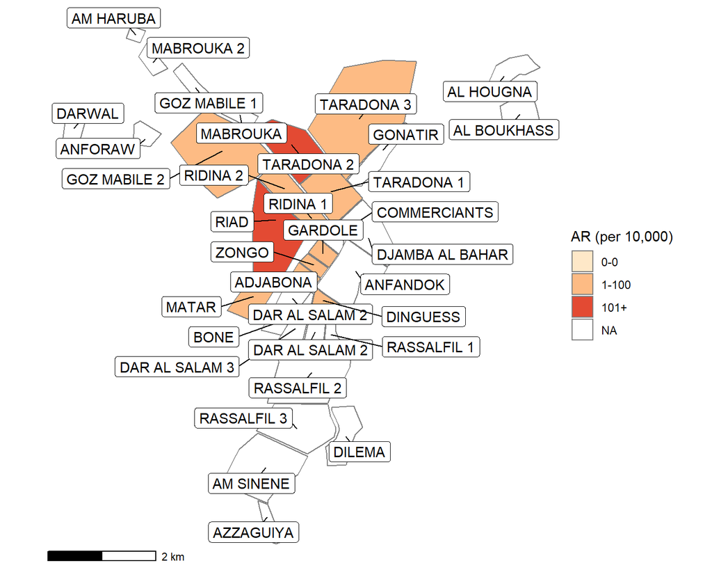

```r
## plotting with polygons ------------------------------------------------------

ggplot() +
  geom_sf(data = mapsub, aes(fill = categories), col = "grey50") + # shapefile as polygon
  coord_sf(datum = NA) + # needed to avoid gridlines being drawn
  annotation_scale() + # add a scalebar
  scale_fill_brewer(drop = FALSE, palette = "OrRd", name = "AR (per 10,000)") +

  # Optional ggrepel section to make labels appear more nicely
  ggrepel::geom_label_repel(data = mapsub, aes(label = Name, geometry = geometry),
                            stat = "sf_coordinates",
                            min.segment.length = 0) +

  theme_void()  # remove coordinates and axes
```

Lastly, **there is an efficient way to create attack rate maps and bar plots of incidence for each epiweek**. Use a **“for loop”** to run the same code for every epi week.

A few things to note about this chunk:

- The first half is very similar to the set-up of the previous map.
- You must also modify the `left_join` command to list the correct variable names (e.g. **modify to join on `Name` instead of `name`**)
- These maps are not labeled with region names.
- The creation of the barplots depends on the object `epicurve_theme`, which was defined in the Time section of the template. If that section is not created, then this object will be missing and cause errors.

The barplots can be limited to quartiers with non-zero attack rates with the following code:

```r
  # Filter values in this_ar to only show quartiers with attack rates > 0 in barplot
  this_ar <- filter(this_ar, `AR (per 10,000)` > 0)
```

And here is the complete code:

```r
## Checklist for plotting in for-loop ------------------------------------------
## - [ ] decide if you would like to show counts, AR or categories of those
## - [ ] define appropriate breaks to ensure legend is uniform by week
## - [ ] replace `Cases (n)` and `AR (per 10,000)` or "categories", appropriately
## - [ ] consider facet wrapping by an overarching unit if have many regions (e.g. by province)

# change region variable to a factor so that zero counts can be included
linelist_cleaned$patient_origin <- as.factor(linelist_cleaned$patient_origin)

# case counts
cases <- linelist_cleaned %>%
  group_by(epiweek) %>%
  count(patient_origin, .drop = FALSE) %>%   # cases for each week by region
  left_join(population_data_region, by = "patient_origin")    # merge population data

# attack rate for region
ar <- attack_rate(cases$n, cases$population, multiplier = 10000) %>%
  # add the region column to table
  bind_cols(select(cases, epiweek, patient_origin), .) %>%
  rename("Region" = patient_origin,
         "Cases (n)" = cases,
         "Population" = population,
         "AR (per 10,000)" = ar,
         "Lower 95%CI" = lower,
         "Upper 95%CI" = upper)
max_cases <- max(cases$n, na.rm = TRUE) # define the maximum number of cases for the color palette
max_ar    <- max(ar$`Upper 95%CI`, na.rm = TRUE)

## define breaks for standardising color palette
breakers <- as.integer(c(
                         # include zero as a standalone group
                         0,
                         # 1 to 4 divisions, snapping the boundaries to the nearest 100
                         find_breaks(n = max_ar, breaks = 4, snap = 100)
             ))

## add a categorical variable using the age_categories function
## nb in this case we arent using ages - but it functions the same way!
ar <- mutate(ar,
             categories = age_categories(`AR (per 10,000)`,
                                         breakers = breakers)
             )
```

**Note: Only results for the first 20 epiweeks are shown. Also, the barplots are filtered to only show quartiers with non-zero attack rates.**

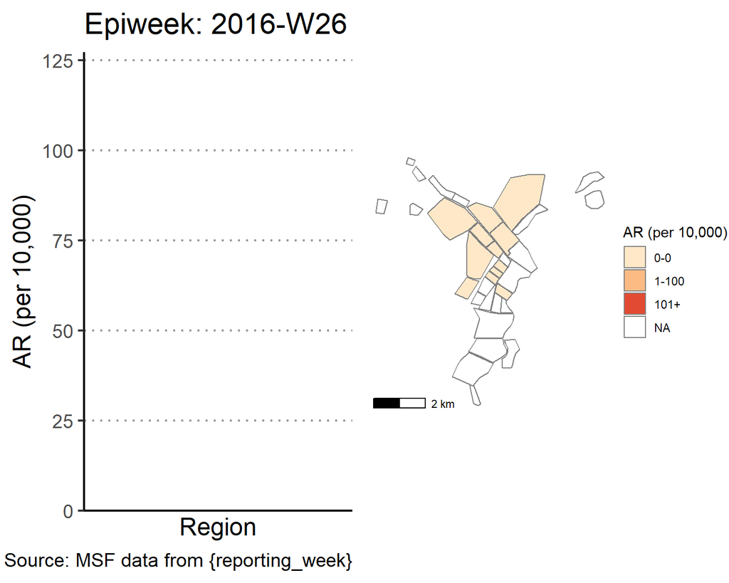

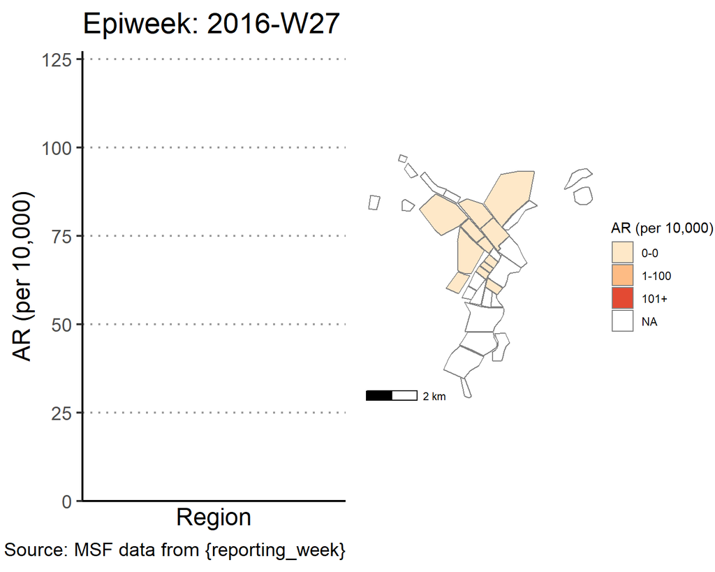

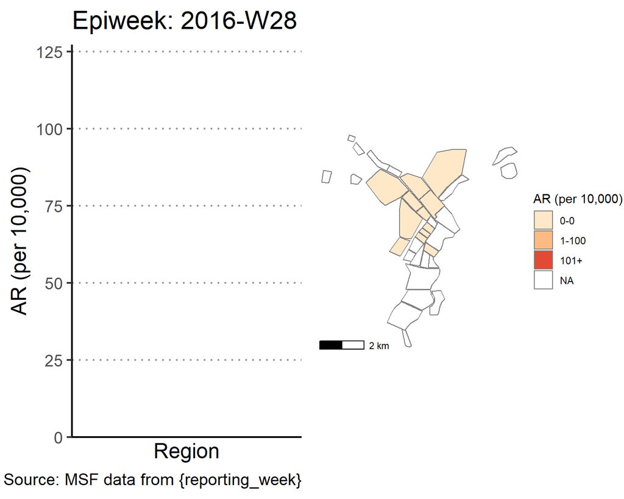

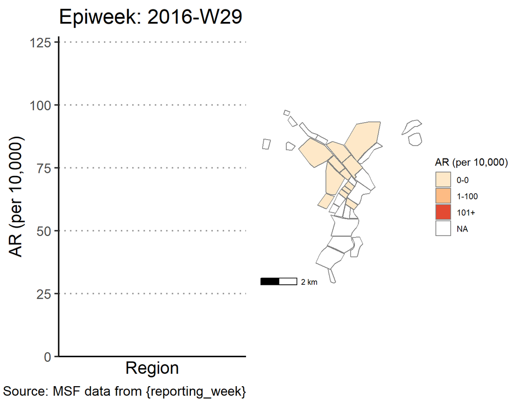

[figure not shown]

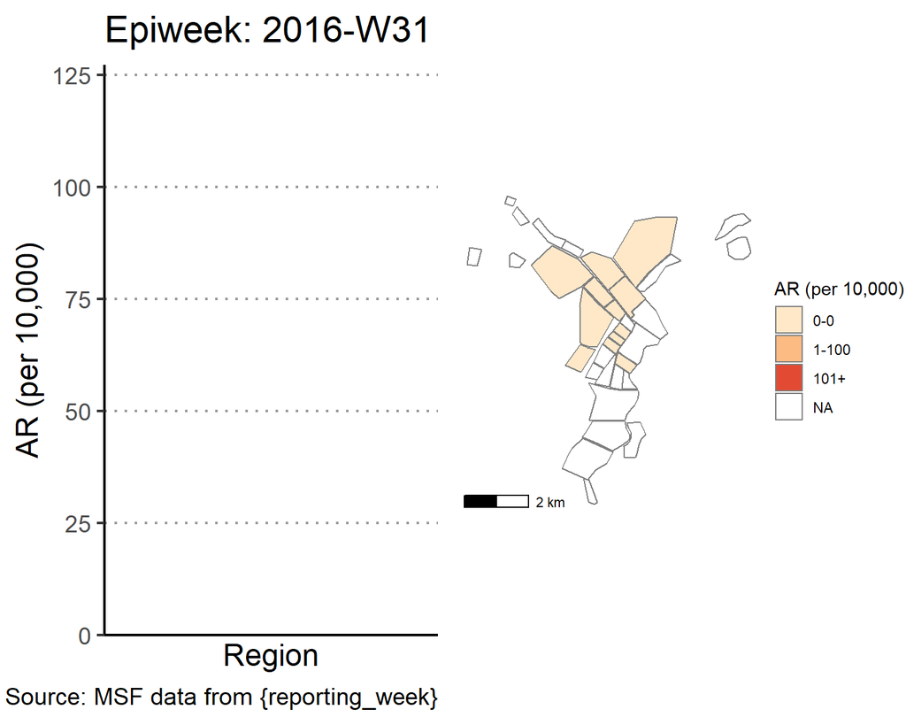

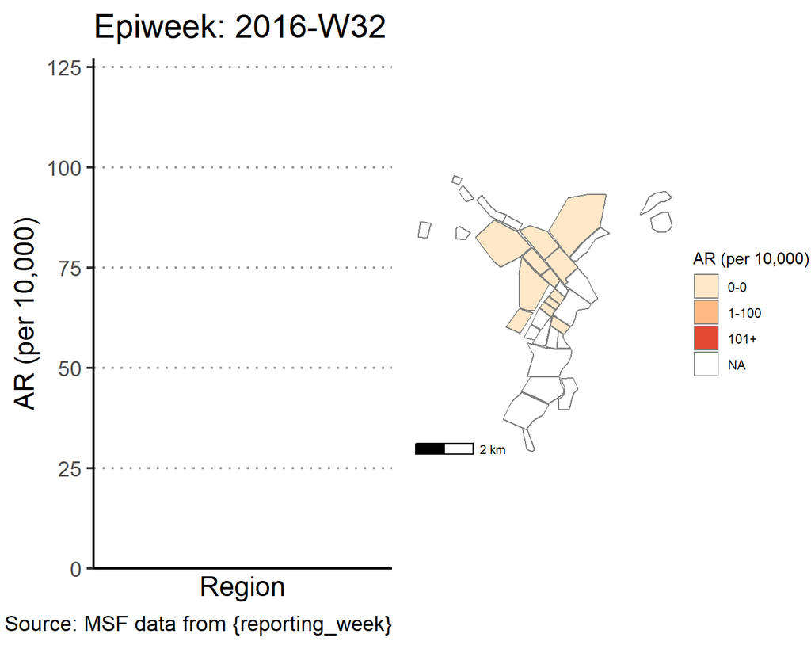

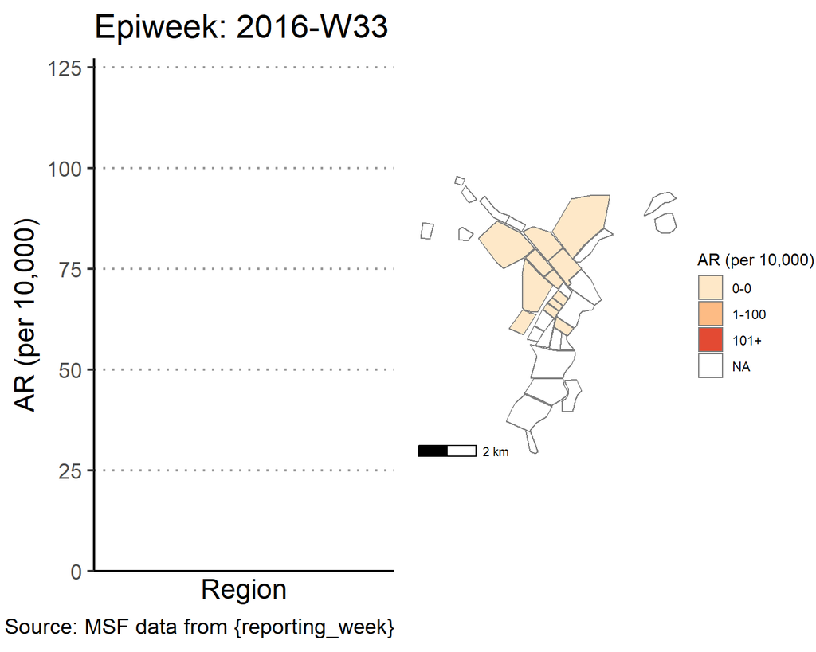

[figure not shown]

[figure not shown]

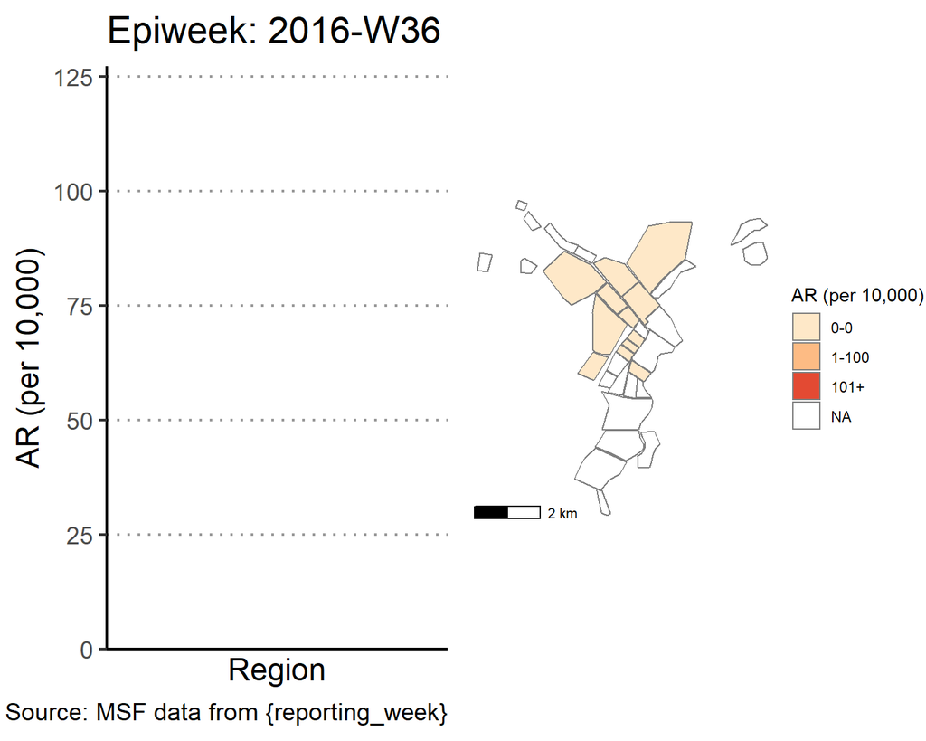

[figure not shown]

[8 more figures not shown]

```r
# All the code is contained within a FOR LOOP that goes through each epiweek, filters and plots the data

for (i in unique(cases$epiweek)) {

  # filters the large ar dataframe for the epiweek being examined ("i")
  this_ar <- filter(ar, epiweek == i)

  ### Create Map for epiweek "i"
  # map
  mapsub <- left_join(map, this_ar, by = c("Name" = "Region"))

  # choropleth
  map_plot <- ggplot() +
    geom_sf(data = mapsub, aes(fill = categories), col = "grey50") + # shapefile as polygon
    coord_sf(datum = NA) + # needed to avoid gridlines being drawn
    annotation_scale() + # add a scalebar
  scale_fill_brewer(drop = FALSE,
                    palette = "OrRd",
                    name = "AR (per 10,000)") +  # color the scale to be perceptually uniform (keep levels)
    theme_void() # remove coordinates and axes

  ### Create barplot for epiweek "i"

  # Filter values in this_ar to only show quartiers with attack rates > 0 in barplot
  this_ar <- filter(this_ar, `AR (per 10,000)` > 0)

  # Create barplot for epiweek "i"
  barplot <- ggplot(this_ar, aes(x = reorder(Region, `AR (per 10,000)`),
                                 y = `AR (per 10,000)`)) +
    geom_bar(stat = "identity", col = "black", fill = "red") + # plot as bars (identity = as is)
    geom_errorbar(aes(ymin = `Lower 95%CI`, ymax = `Upper 95%CI`), width = 0.2) + # add CIs
    scale_y_continuous(expand = c(0, 0), limits = c(0, max_ar)) +  # set origin for axes
    # add labels to axes and below chart
    labs(x = "Region", y = "AR (per 10,000)",
         captions = ("Source: MSF data from {reporting_week}")) +
    epicurve_theme


  # combine the barplot and map plot into one for epiweek "i"
  print(
    cowplot::plot_grid(
      barplot + labs(title = str_glue("Epiweek: {i}")),
      map_plot,
      nrow = 1,
      align = "h",
      axis = "tb"
    )
  )
}
```